# Covid 19 Death and Vaccination EDA (Worldwide)

### 1/22/2020 - 2/15/2023

#### Lets take a look at the raw global data tables from Johns's Hopkins (Kaggle)

|  | Country/Region | Province/State | Lat | Long | 1/22/20 | 1/23/20 | 1/24/20 | 1/25/20 | 1/26/20 | 1/27/20 | ... | 2/6/23 | 2/7/23 | 2/8/23 | 2/9/23 | 2/10/23 | 2/11/23 | 2/12/23 | 2/13/23 | 2/14/23 | 2/15/23 |
| --- | --- | --- | --- | --- | --- | --- | --- | --- | --- | --- | --- | --- | --- | --- | --- | --- | --- | --- | --- | --- | --- |
| 0 | Afghanistan | NaN | 33.93911 | 67.709953 | 0 | 0 | 0 | 0 | 0 | 0 | ... | 7896 | 7896 | 7896 | 7896 | 7896 | 7896 | 7896 | 7896 | 7896 | 7896 |
| 1 | Albania | NaN | 41.15330 | 20.168300 | 0 | 0 | 0 | 0 | 0 | 0 | ... | 3596 | 3596 | 3596 | 3596 | 3596 | 3596 | 3596 | 3596 | 3596 | 3596 |
| 2 | Algeria | NaN | 28.03390 | 1.659600 | 0 | 0 | 0 | 0 | 0 | 0 | ... | 6881 | 6881 | 6881 | 6881 | 6881 | 6881 | 6881 | 6881 | 6881 | 6881 |
| 3 | Andorra | NaN | 42.50630 | 1.521800 | 0 | 0 | 0 | 0 | 0 | 0 | ... | 165 | 165 | 165 | 165 | 165 | 165 | 165 | 165 | 165 | 165 |
| 4 | Angola | NaN | -11.20270 | 17.873900 | 0 | 0 | 0 | 0 | 0 | 0 | ... | 1931 | 1931 | 1931 | 1931 | 1931 | 1931 | 1931 | 1931 | 1931 | 1931 |

5 rows × 1125 columns

```
<class 'pandas.core.frame.DataFrame'>
RangeIndex: 289 entries, 0 to 288
Columns: 1125 entries, Country/Region to 2/15/23
dtypes: float64(2), int64(1121), object(2)
memory usage: 2.5+ MB
```

|  | count | mean | std | min | 25% | 50% | 75% | max |
| --- | --- | --- | --- | --- | --- | --- | --- | --- |
| Afghanistan | 1120.0 | 7.050000 | 15.765575 | 0.0 | 0.0 | 1.0 | 6.0 | 159.0 |
| Albania | 1120.0 | 3.210714 | 4.491106 | 0.0 | 0.0 | 1.0 | 5.0 | 21.0 |
| Algeria | 1120.0 | 6.143750 | 7.482828 | 0.0 | 0.0 | 4.0 | 9.0 | 49.0 |
| Andorra | 1120.0 | 0.147321 | 0.537006 | -2.0 | 0.0 | 0.0 | 0.0 | 7.0 |
| Angola | 1120.0 | 1.724107 | 3.068149 | -3.0 | 0.0 | 0.0 | 2.0 | 30.0 |
| ... | ... | ... | ... | ... | ... | ... | ... | ... |
| West Bank and Gaza | 1120.0 | 5.096429 | 11.075240 | 0.0 | 0.0 | 0.0 | 7.0 | 268.0 |
| Winter Olympics 2022 | 1120.0 | 0.000000 | 0.000000 | 0.0 | 0.0 | 0.0 | 0.0 | 0.0 |
| Yemen | 1120.0 | 1.927679 | 4.421608 | 0.0 | 0.0 | 0.0 | 2.0 | 60.0 |
| Zambia | 1120.0 | 3.616964 | 9.663354 | 0.0 | 0.0 | 0.0 | 2.0 | 72.0 |
| Zimbabwe | 1120.0 | 5.055357 | 12.746254 | 0.0 | 0.0 | 0.0 | 3.0 | 107.0 |

198 rows × 8 columns

|  | Total | Percent |
| --- | --- | --- |
| Province/State | 198 | 0.685121 |
| Lat | 2 | 0.006920 |
| Long | 2 | 0.006920 |
| Country/Region | 0 | 0.000000 |
| 2/4/22 | 0 | 0.000000 |
| ... | ... | ... |
| 2/3/21 | 0 | 0.000000 |
| 2/4/21 | 0 | 0.000000 |
| 2/5/21 | 0 | 0.000000 |
| 2/6/21 | 0 | 0.000000 |
| 2/15/23 | 0 | 0.000000 |

1125 rows × 2 columns

--lets remove the provice/state columns - there is a lot of missing data there, but could cause issues too, we will have to check

```
--------number of single country records, and number of provincial records---------
False    201
True      88
dtype: int64
--------number of records per country---------
Country/Region
Australia          8
Canada            16
China             34
Denmark            3
France            12
Netherlands        5
New Zealand        3
United Kingdom    15
dtype: int64
```

some of the data is in provincial format, some is single value for the country

| Country/Region | Lat | Long | 1/22/20 | 1/23/20 | 1/24/20 | 1/25/20 | 1/26/20 | 1/27/20 | 1/28/20 | 1/29/20 | ... | 2/6/23 | 2/7/23 | 2/8/23 | 2/9/23 | 2/10/23 | 2/11/23 | 2/12/23 | 2/13/23 | 2/14/23 | 2/15/23 |
| --- | --- | --- | --- | --- | --- | --- | --- | --- | --- | --- | --- | --- | --- | --- | --- | --- | --- | --- | --- | --- | --- |
| Afghanistan | 33.93911 | 67.709953 | 0 | 0 | 0 | 0 | 0 | 0 | 0 | 0 | ... | 7896 | 7896 | 7896 | 7896 | 7896 | 7896 | 7896 | 7896 | 7896 | 7896 |
| Albania | 41.15330 | 20.168300 | 0 | 0 | 0 | 0 | 0 | 0 | 0 | 0 | ... | 3596 | 3596 | 3596 | 3596 | 3596 | 3596 | 3596 | 3596 | 3596 | 3596 |
| Algeria | 28.03390 | 1.659600 | 0 | 0 | 0 | 0 | 0 | 0 | 0 | 0 | ... | 6881 | 6881 | 6881 | 6881 | 6881 | 6881 | 6881 | 6881 | 6881 | 6881 |
| Andorra | 42.50630 | 1.521800 | 0 | 0 | 0 | 0 | 0 | 0 | 0 | 0 | ... | 165 | 165 | 165 | 165 | 165 | 165 | 165 | 165 | 165 | 165 |
| Angola | -11.20270 | 17.873900 | 0 | 0 | 0 | 0 | 0 | 0 | 0 | 0 | ... | 1931 | 1931 | 1931 | 1931 | 1931 | 1931 | 1931 | 1931 | 1931 | 1931 |

5 rows × 1123 columns

--If we scroll to the right, we can see that the count is cumulative. to get the deaths per day, we would need to substract day from final day

|  | 1/27/20 | 1/28/20 | 1/29/20 | 1/30/20 | 1/31/20 | 2/1/20 | 2/2/20 | 2/3/20 | 2/4/20 | 2/5/20 | ... | 2/6/23 | 2/7/23 | 2/8/23 | 2/9/23 | 2/10/23 | 2/11/23 | 2/12/23 | 2/13/23 | 2/14/23 | 2/15/23 |
| --- | --- | --- | --- | --- | --- | --- | --- | --- | --- | --- | --- | --- | --- | --- | --- | --- | --- | --- | --- | --- | --- |
| 0 | 0 | 0 | 0 | 0 | 0 | 0 | 0 | 0 | 0 | 0 | ... | 0 | 0 | 0 | 0 | 0 | 0 | 0 | 0 | 0 | NaN |
| 1 | 0 | 0 | 0 | 0 | 0 | 0 | 0 | 0 | 0 | 0 | ... | 0 | 0 | 0 | 0 | 0 | 0 | 0 | 0 | 0 | NaN |
| 2 | 0 | 0 | 0 | 0 | 0 | 0 | 0 | 0 | 0 | 0 | ... | 0 | 0 | 0 | 0 | 0 | 0 | 0 | 0 | 0 | NaN |
| 3 | 0 | 0 | 0 | 0 | 0 | 0 | 0 | 0 | 0 | 0 | ... | 0 | 0 | 0 | 0 | 0 | 0 | 0 | 0 | 0 | NaN |
| 4 | 0 | 0 | 0 | 0 | 0 | 0 | 0 | 0 | 0 | 0 | ... | 0 | 0 | 0 | 0 | 0 | 0 | 0 | 0 | 0 | NaN |

5 rows × 1116 columns

|  | Country/Region | 1/27/20 | 1/28/20 | 1/29/20 | 1/30/20 | 1/31/20 | 2/1/20 | 2/2/20 | 2/3/20 | 2/4/20 | ... | 2/6/23 | 2/7/23 | 2/8/23 | 2/9/23 | 2/10/23 | 2/11/23 | 2/12/23 | 2/13/23 | 2/14/23 | 2/15/23 |
| --- | --- | --- | --- | --- | --- | --- | --- | --- | --- | --- | --- | --- | --- | --- | --- | --- | --- | --- | --- | --- | --- |
| 0 | Afghanistan | 0 | 0 | 0 | 0 | 0 | 0 | 0 | 0 | 0 | ... | 0 | 0 | 0 | 0 | 0 | 0 | 0 | 0 | 0 | NaN |
| 1 | Albania | 0 | 0 | 0 | 0 | 0 | 0 | 0 | 0 | 0 | ... | 0 | 0 | 0 | 0 | 0 | 0 | 0 | 0 | 0 | NaN |
| 2 | Algeria | 0 | 0 | 0 | 0 | 0 | 0 | 0 | 0 | 0 | ... | 0 | 0 | 0 | 0 | 0 | 0 | 0 | 0 | 0 | NaN |
| 3 | Andorra | 0 | 0 | 0 | 0 | 0 | 0 | 0 | 0 | 0 | ... | 0 | 0 | 0 | 0 | 0 | 0 | 0 | 0 | 0 | NaN |
| 4 | Angola | 0 | 0 | 0 | 0 | 0 | 0 | 0 | 0 | 0 | ... | 0 | 0 | 0 | 0 | 0 | 0 | 0 | 0 | 0 | NaN |

5 rows × 1117 columns

--We need to drop that most recent day since we cant calculate a value form the cumulative sum for that day

|  | Country/Region | 1/27/20 | 1/28/20 | 1/29/20 | 1/30/20 | 1/31/20 | 2/1/20 | 2/2/20 | 2/3/20 | 2/4/20 | ... | 2/6/23 | 2/7/23 | 2/8/23 | 2/9/23 | 2/10/23 | 2/11/23 | 2/12/23 | 2/13/23 | 2/14/23 | total_deaths |
| --- | --- | --- | --- | --- | --- | --- | --- | --- | --- | --- | --- | --- | --- | --- | --- | --- | --- | --- | --- | --- | --- |
| 0 | Afghanistan | 0 | 0 | 0 | 0 | 0 | 0 | 0 | 0 | 0 | ... | 0 | 0 | 0 | 0 | 0 | 0 | 0 | 0 | 0 | 7896 |
| 1 | Albania | 0 | 0 | 0 | 0 | 0 | 0 | 0 | 0 | 0 | ... | 0 | 0 | 0 | 0 | 0 | 0 | 0 | 0 | 0 | 3596 |
| 2 | Algeria | 0 | 0 | 0 | 0 | 0 | 0 | 0 | 0 | 0 | ... | 0 | 0 | 0 | 0 | 0 | 0 | 0 | 0 | 0 | 6881 |
| 3 | Andorra | 0 | 0 | 0 | 0 | 0 | 0 | 0 | 0 | 0 | ... | 0 | 0 | 0 | 0 | 0 | 0 | 0 | 0 | 0 | 165 |
| 4 | Angola | 0 | 0 | 0 | 0 | 0 | 0 | 0 | 0 | 0 | ... | 0 | 0 | 0 | 0 | 0 | 0 | 0 | 0 | 0 | 1931 |

5 rows × 1117 columns

|  | Country/Region | total_deaths |
| --- | --- | --- |
| 76 | Holy See | 0 |
| 5 | Antarctica | 0 |
| 185 | Tuvalu | 0 |
| 197 | Winter Olympics 2022 | 0 |
| 170 | Summer Olympics 2020 | 0 |

--We can see there are at least two "events" (the olympics), good to be aware of. We will leave them in for now.

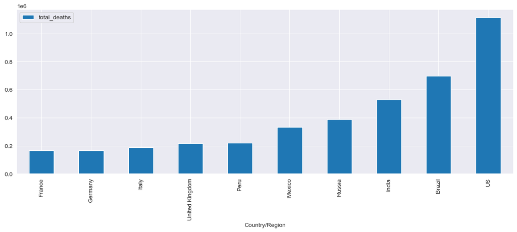

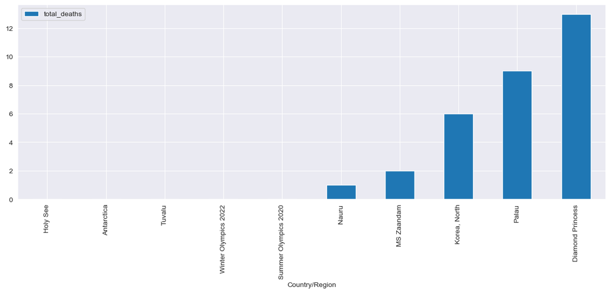

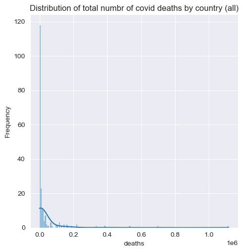

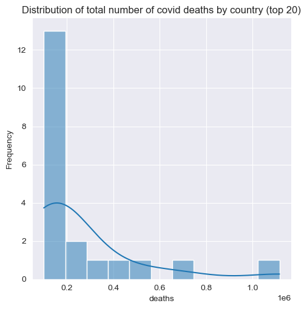

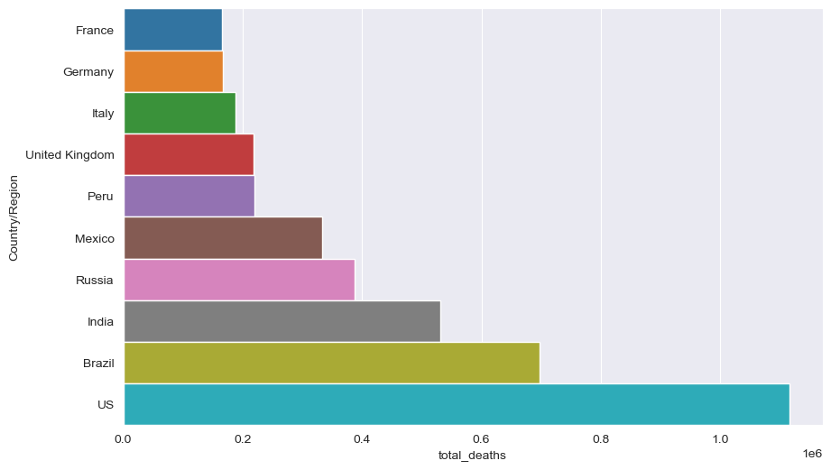

[figure not shown]

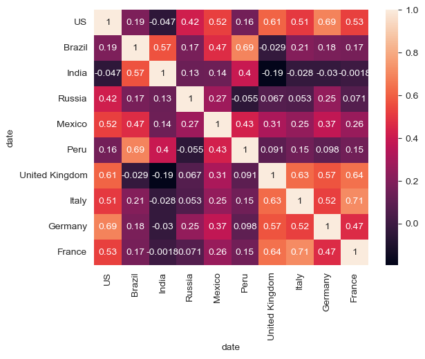

# lets just look at the US data

### Questions to explore:

- What is the total number of deaths from covid in the US?
- What is the Distribution of the daily death counts?
- What is the mean and standard deviation of number of daily deaths from covid in the US?
- What is the trend in deaths in the US from covid like over the duration of the pandemic?

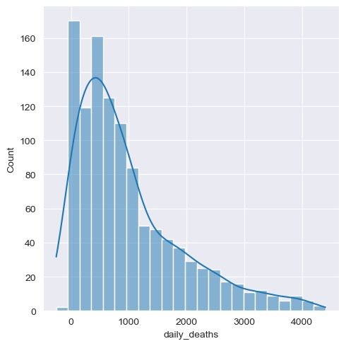

```
1115564
```

```
1000.5058295964126
```

```
931.1271092807036
```

|  | daily_deaths |
| --- | --- |
| count | 1115 |
| unique | 851 |
| top | 0 |
| freq | 34 |

```
427.41
```

--The distribution of daily deaths in the US is right skewed.  
Lets check the trend in the US Covid death rate by plotting number of deaths over time

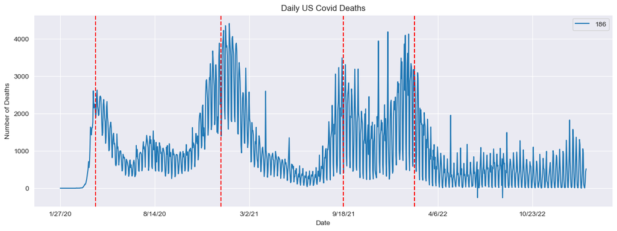